# Computational Musicology Portfolio

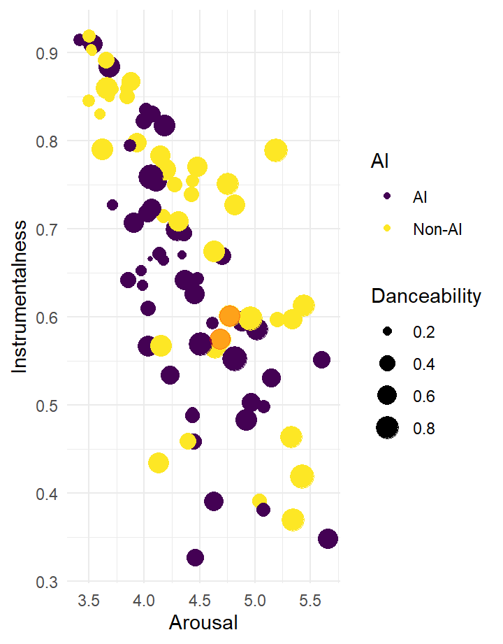

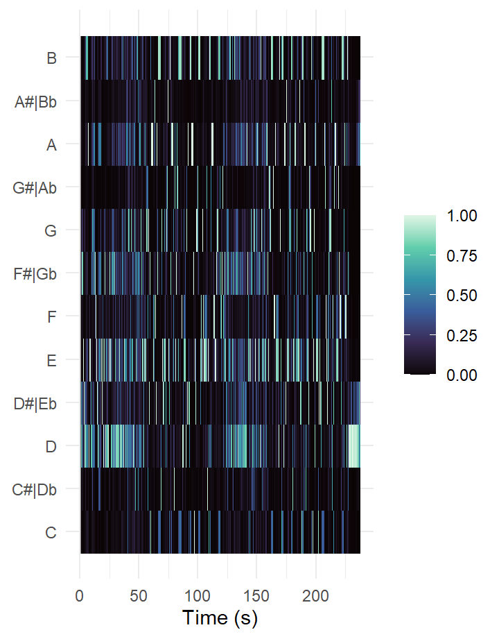

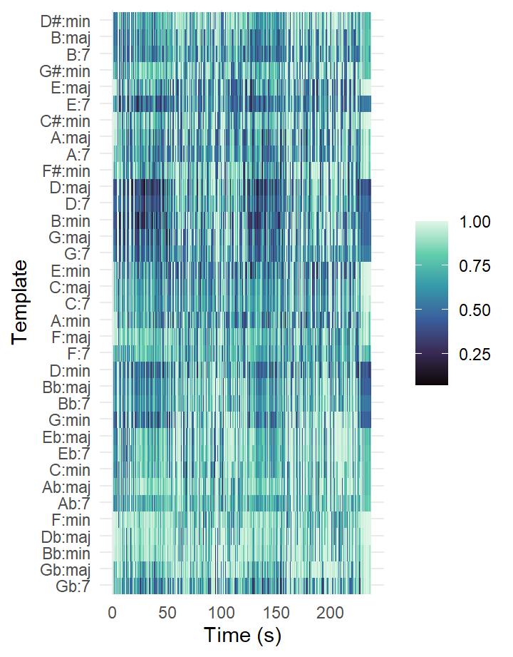

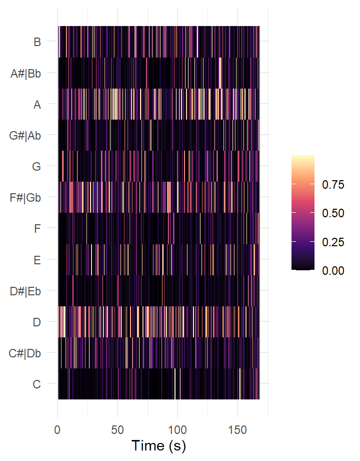

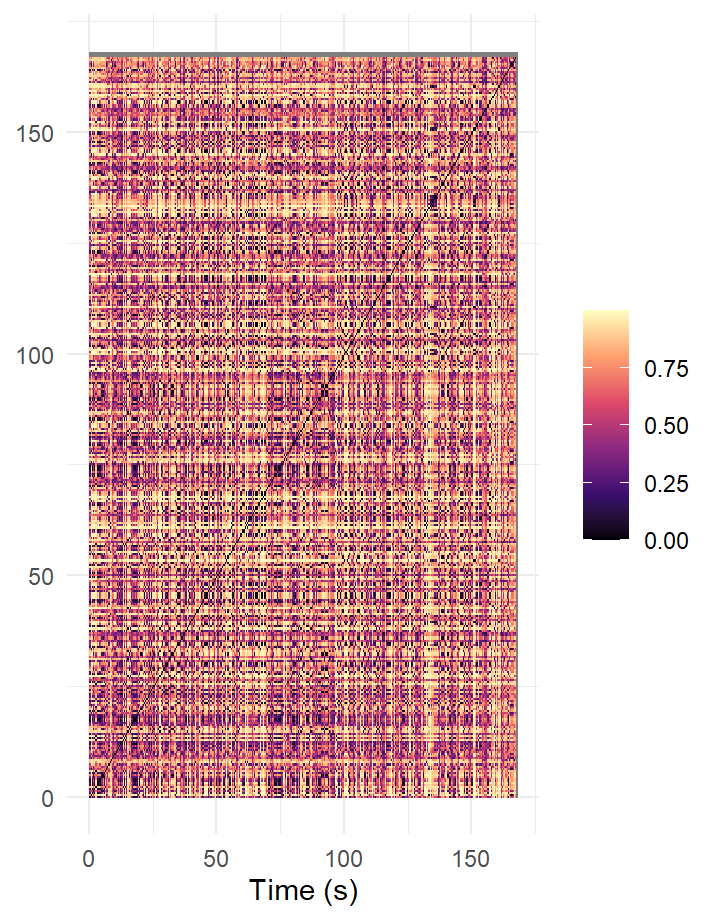

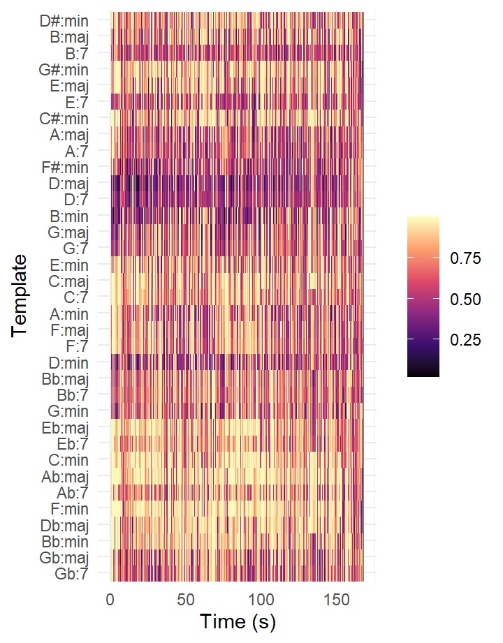

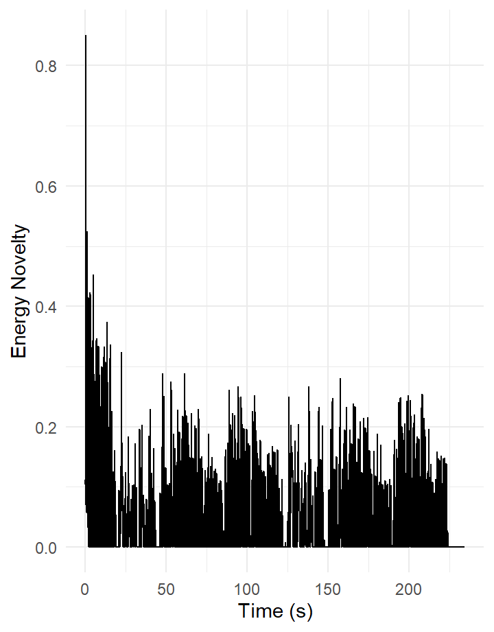

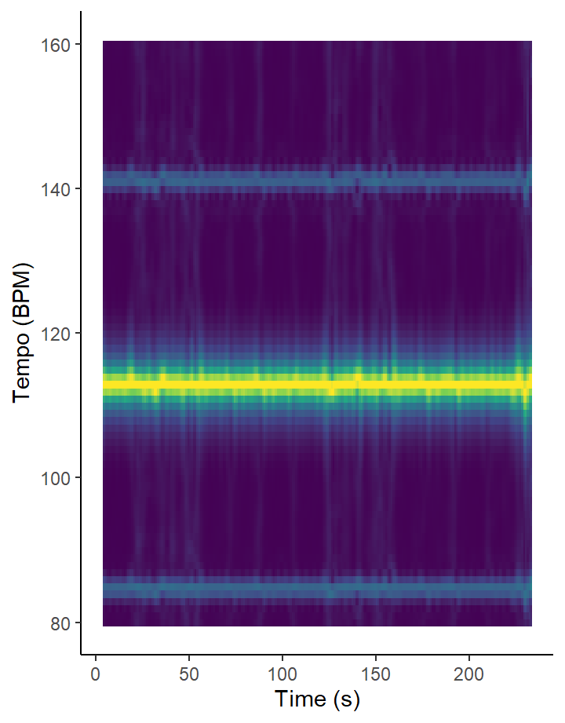

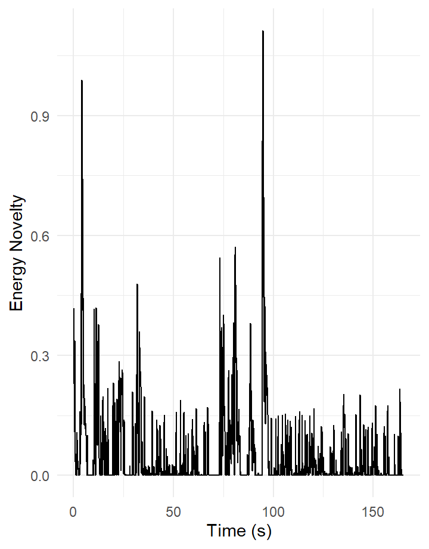

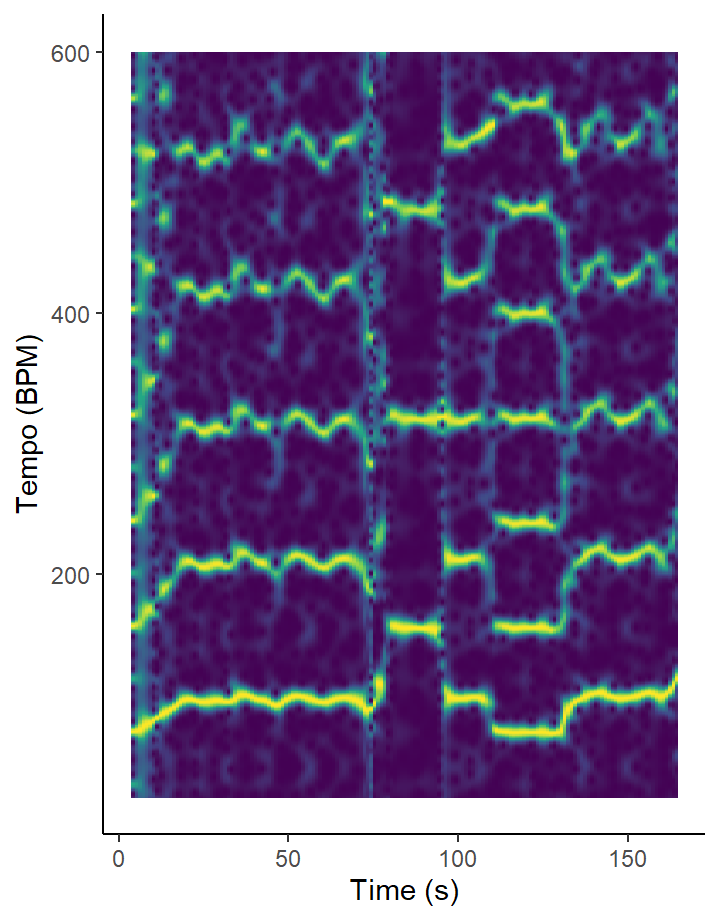

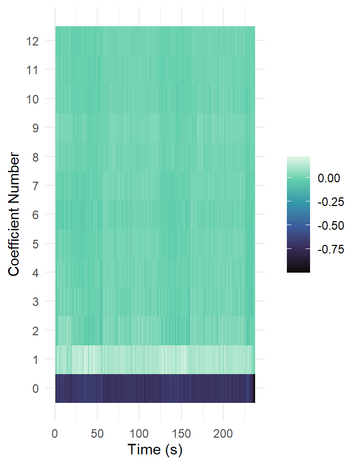

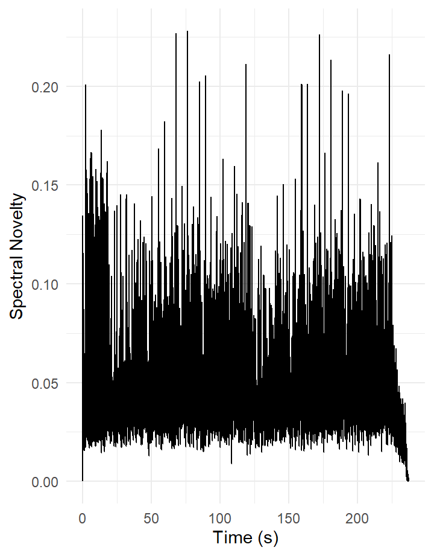

[8 more figures not shown]

# Introduction

### Song Information

Welcome to my portfolio, where I explore two important tracks that sparked my love for electronic music: “Lost” by Kontinuum and “Stay with Me” by Mendum. The first caught my attention a few years ago with its breezy, summery, laid-back feel and consistent rhythm, while the second inspired me in 2014 with its energetic feel and dramatic drops.

#### Lost - Kontinuum

“Lost” is a song from the indie dance genre and stands out for its mid-tempo groove and warm, summery feel. When it’s viewed alongside the entire corpus, its instrumentalness, arousal, and valence all hover around average levels. Meanwhile, its danceability sits above the midpoint, thanks to a steady beat that makes the song fairly accessible and enjoyable for listeners.

[interactive chart not shown]

#### Stay with me - Mendum

“Stay with Me” is song from the drumstep genre and is therefore faster in tempo, but its instrumentalness and arousal features are close to the corpus mean. Its valence also remains moderate, although the track’s energetic drops can lend occasional bursts of intensity. Similar to “Lost” danceability stays above average, ensuring a strong rhythmic drive. Despite these similarities, the speed and dramatic transitions of “Stay with Me” give it a noticeably different flavor than the laid-back appeal of “Lost.”

[interactive chart not shown]

### Visualisation corpus

This is a visualization of the whole class corpus based on the highest performing features, which are explained in detail in the ‘Classification’ tab. My songs are highlighted in orange and are both Non-AI. The songs seem closely related in the graph but are actually totally different in nature and will be explored in this portfolio.

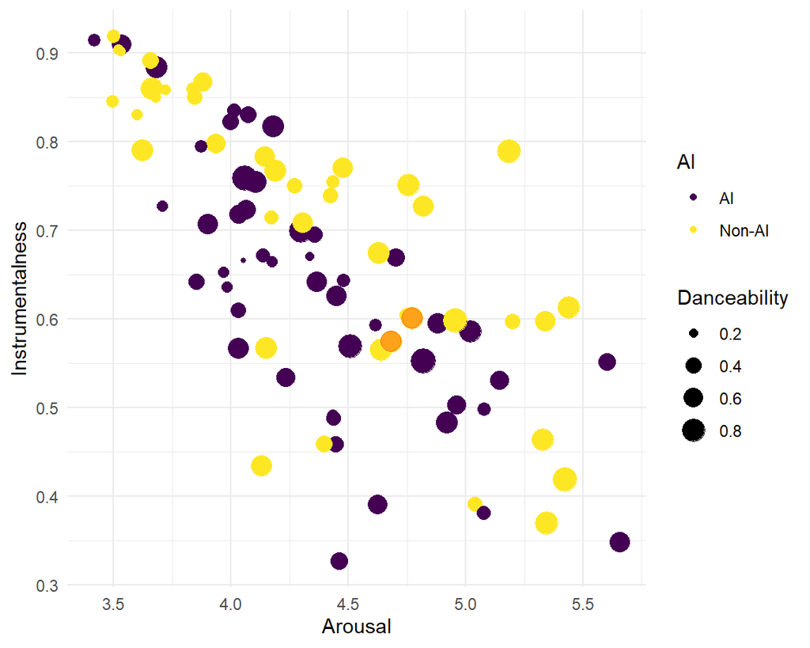

# Pitch & Harmony

### Lost

#### Pitch

Pitch is the perceived highness or lowness of a sound, determined by its frequency. It will be visualized through the following graphs.

#### Chromagram

The chromagram shows that the song the most prominent note is D and the other highlighted notes are in the key for D major, which is the key of the song.

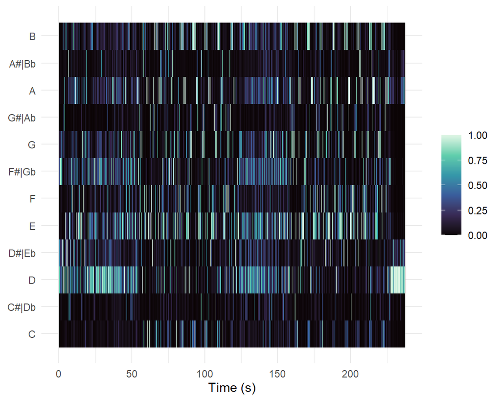

#### Chordogram

A chordogram uses the chroma features to cluster the notes into the major, minor or seventh chords based on the major and minor key. “Lost” uses funky but the same 4 chords before the drop which aren’t exactly major or minor and is the reason why there is a lot of relative major/minor shifts. Also, in the drop the chord progression interchanges every couple measures and explains why those sections are pretty unreadable.

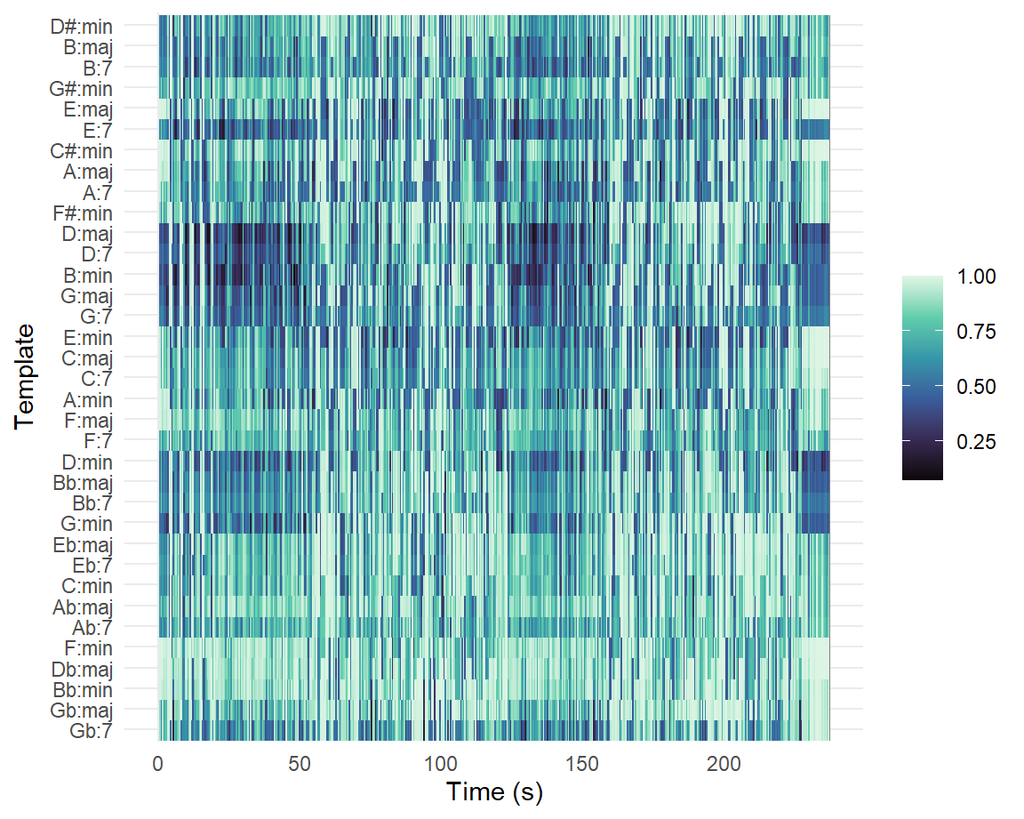

### Stay with me

#### Chromagram

‘Stay with me’ is also in the key of D major, like ‘Lost’, but it is way more chaotic and doesn’t really have a pattern.

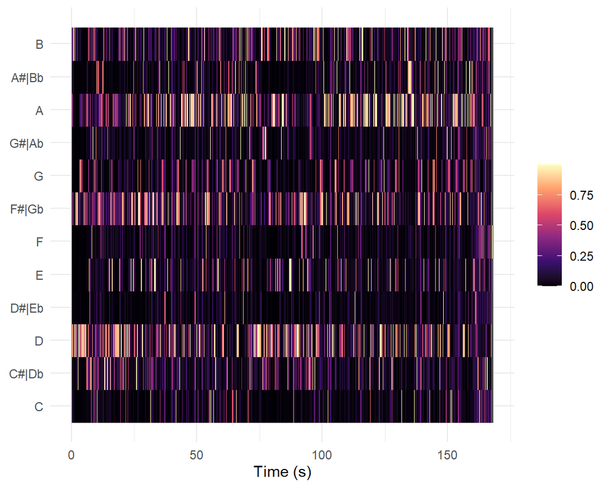

#### Chroma similarity

The randomness of the song is truly captivated in the chroma-based self-similarity matrix. A chroma-based self-similarity matrix is a visualization that shows how similar segments of a musical piece are to each other based on their chroma features. This matrix however shows no real clear overlap of sections in the song, since there are no other diagonal lines (except for the true diagonal) and no giant boxes that show repeating sections.

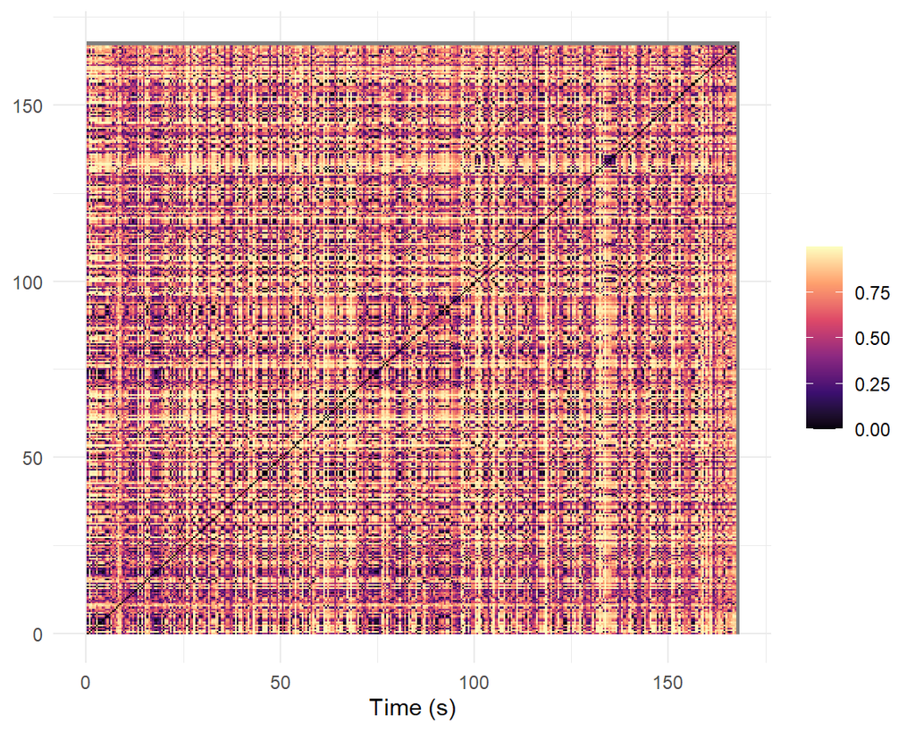

I love drumstep <3

#### Chordogram

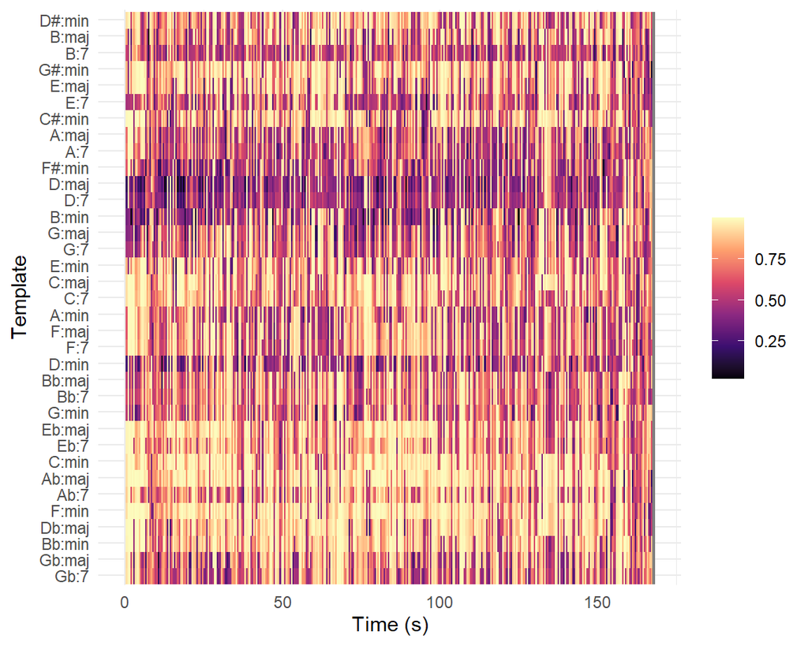

# Tempo & Energy

### Lost

#### Tempo & Energy

Tempo is the speed of a song, measured in beats per minute (BPM) and energy is the overall intensity or activity level of the music, influenced by loudness and rhythm. The following graphs visualizes these features.

#### Energy novelty

‘Lost’ has a very stable beat and is smoothly flowing throughout the whole song, which you can see in this energy novelty graph. The energy peaks only at the beginning when the beat starts but after that the energy stays quite low the entire way through. The two drops in the song are at 50 seconds and 160 seconds which are not very present at all, which is due to it’s laid-back nature.

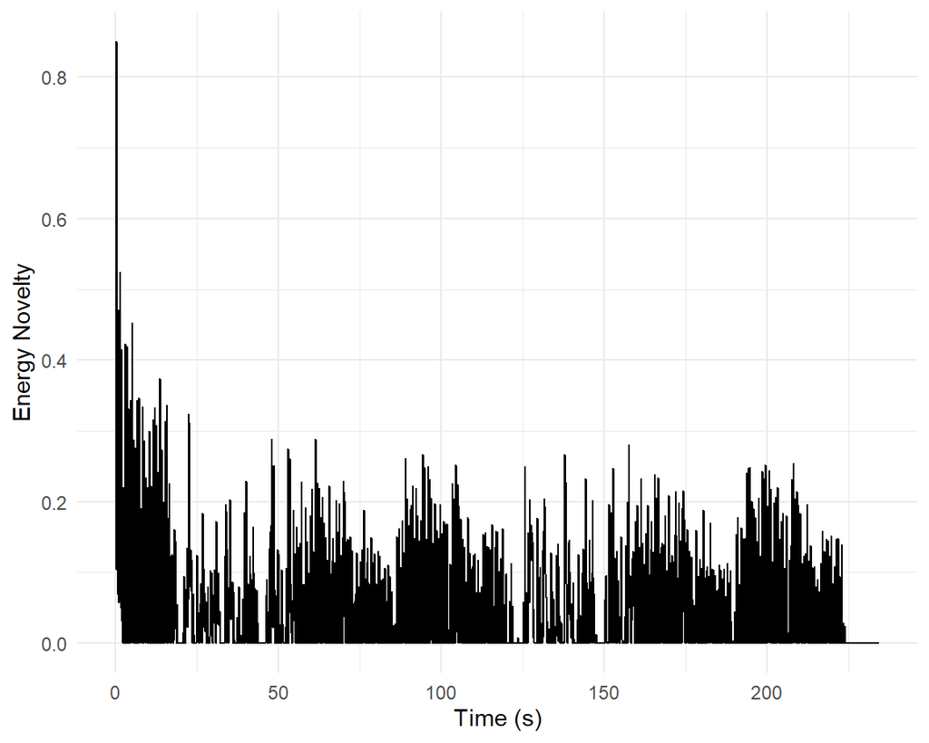

#### Tempogram

I visualized the tempo of ‘Lost’ using a *cyclic* tempogram, because the song has a very stable rhythm that does not change at all during the entire song. It is almost a perfect straight line since it is electronically made and is not performed by a human. The BPM can be read and looks in between 110-115 which is correct since the BPM of the song is 113.

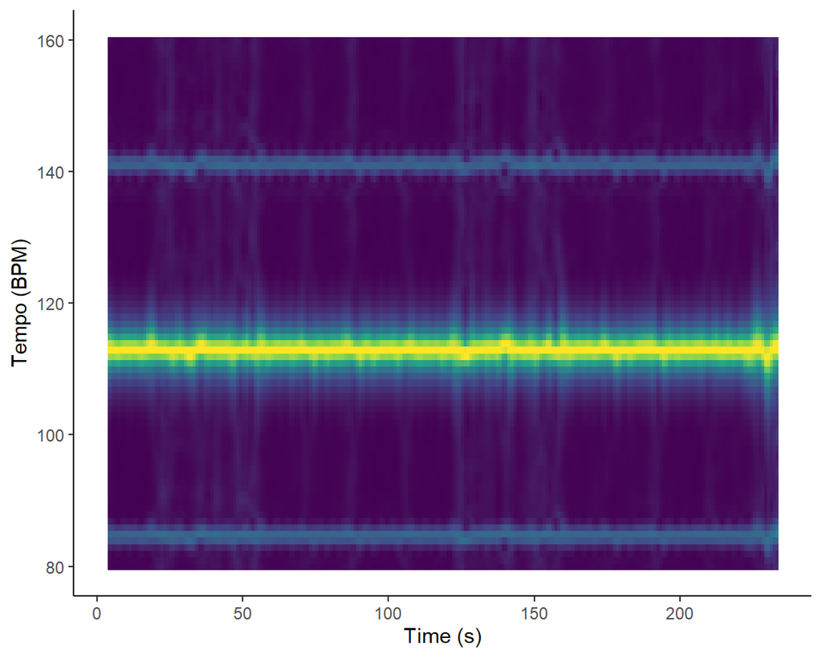

### Stay with me

#### Energy novelty

The song ‘Stay with me’ starts with a bit of piano and vocals and when the first bass comes into play and after that there is a buildup until the 30 seconds mark where the beat drops and goes off rhythm, but interestingly it is not the highest energy peak. That is the second drop of the song at 90 seconds, which has more silence before it drops and explains the peak.

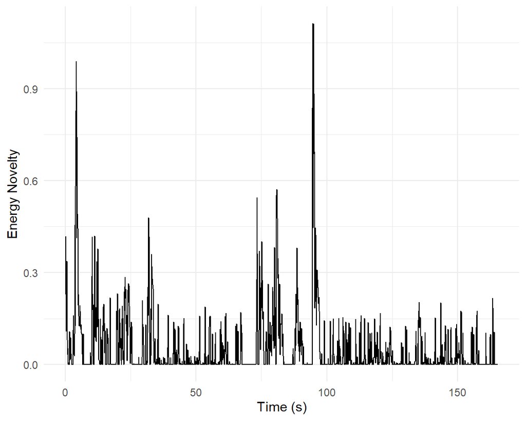

#### Tempogram

In contrast to the tempogram of ‘Lost’, this tempogram of ‘Stay with me’ is not stable at all mostly due to the drums of the song. The drums of the song are not exactly on the beat of the song and differ constantly due to the half-time drum patterns. It explains the wiggly lines up until the 75 second mark. However, after the chorus the tempo does not change but there is obviously a jump in tempo up until the 90 seconds mark. This part has no drums at all so it is basing the beat on the piano part of the song which weirdly enough is the *actual bpm* of 160. Also, interestingly enough there is a trend throughout the whole song of a bpm of 320 which is double the actual bpm.

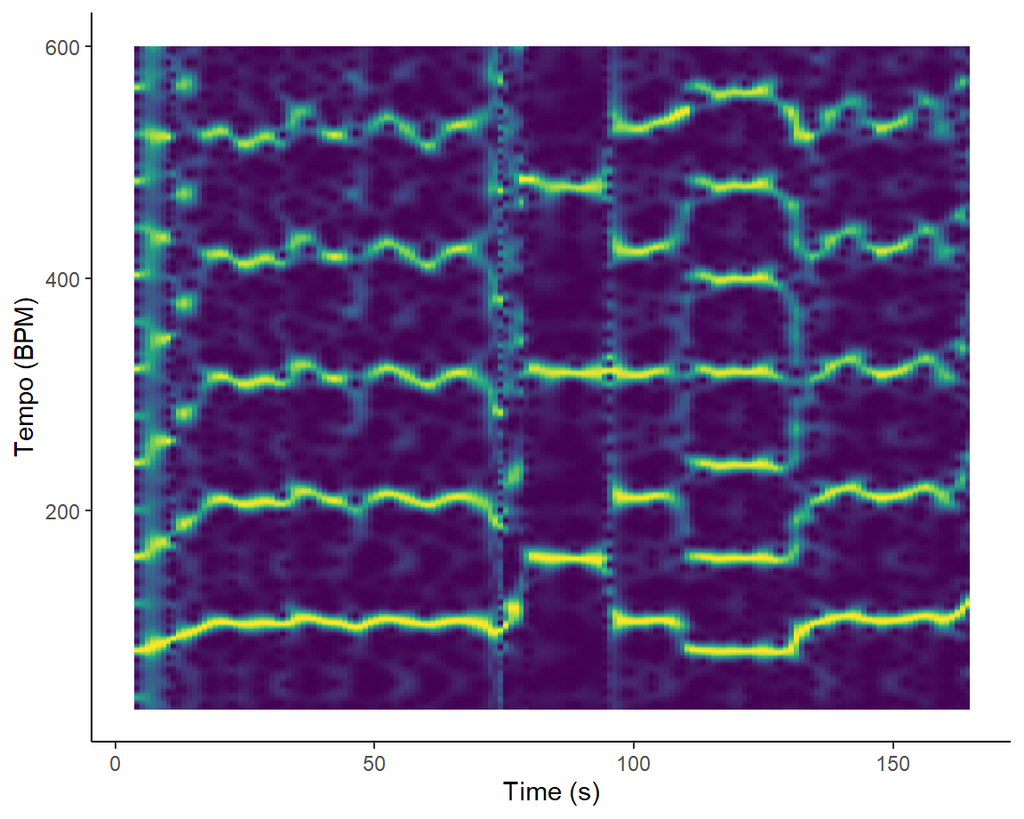

# Timbre

### Lost

#### Timbre

Timbre is the “tone color” or sound quality that makes an instrument or voice uniquely recognizable. The following graphs can visualize those changes in different ways. The graphs can show differences in instrument changes, chord progressions and melodic transitions.

#### Cepstogram

This cepstogram shows bright almost constant lower coefficients, which shows that there is a stable fundamental timbre in the song, the summery chill vibe. Around 55 sec and 160 sec there is a drop in cepstral energy followed by a surge of energy that lasts about a minute each. This shows that the song has a instrumental break before the 2 drops which create a lot more cepstral energy than the rest of the song.

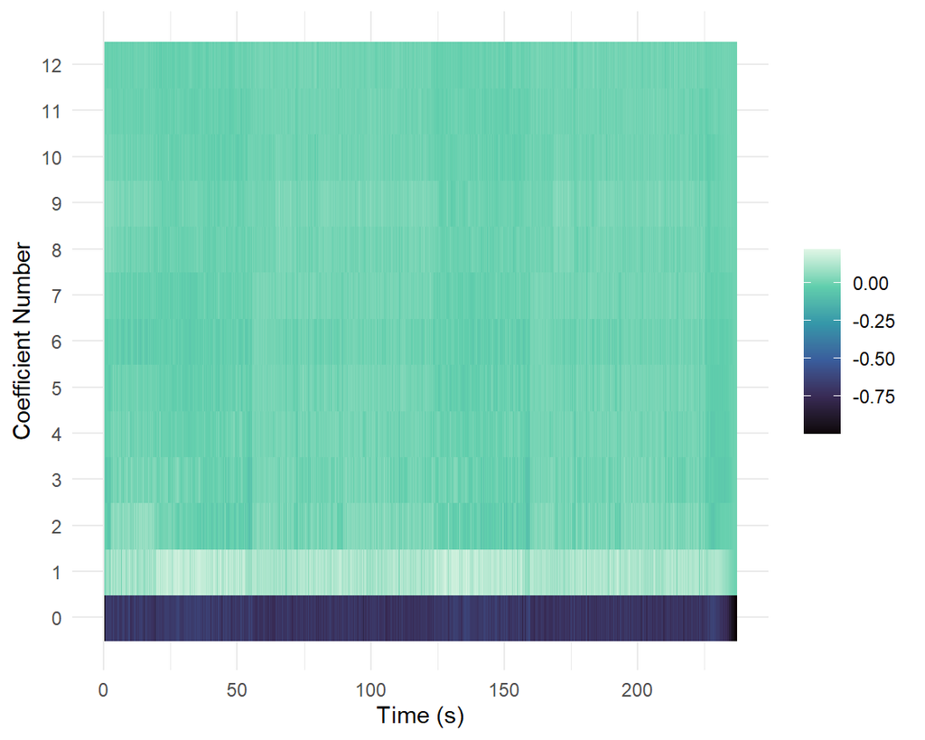

#### Spectral novelty

This spectral novelty graph shows the spectral energy at different moments in time. The same patterns are visivle as in the cepstogram. Between 55-120 and 160-225 seconds is the average spectral energy a bit higher than then the other parts.

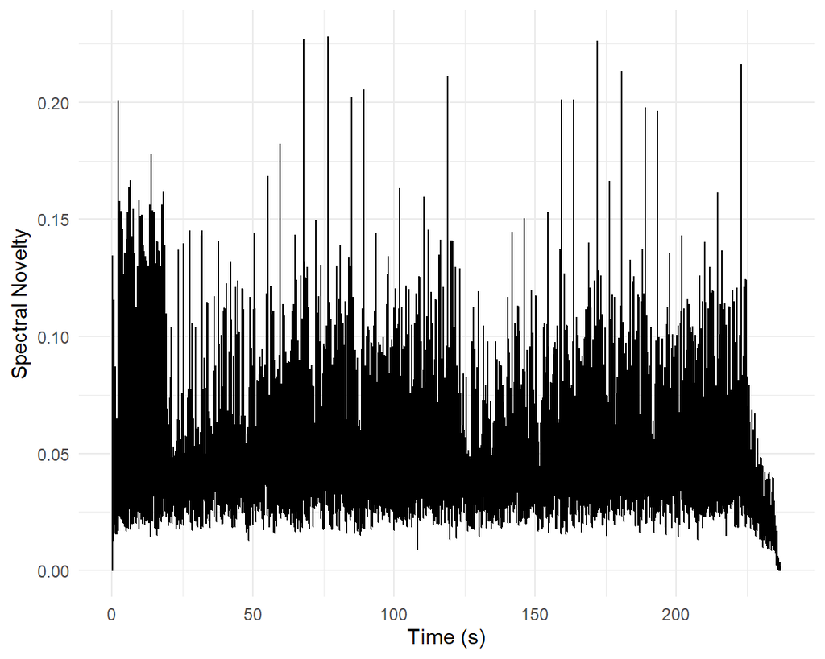

#### Timbre similarity

The song stays true in it’s summery vibe throughout the song and can be shown through the timbre-based self-similarity matrix. The self-similarity matrix is a visualization of the song’s timbre features compared with itself. The large squares and long diagonal lines thorugh those boxes indicate that the songs timbre throughout the song is very consistent.

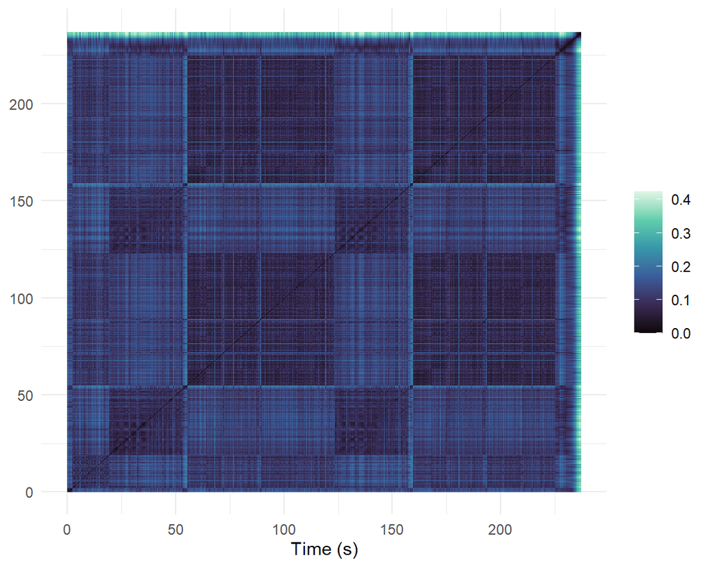

### Stay with me

#### Cepstogram

The cepstogram of ‘Stay with me’ shows between 35 seconds a dip in cepstral energy immediately followed by high cepsteral energy and unstable lower coefficient until 70 seconds which correlates with the first drop of the song. The second drop starts at 90 seconds and goes on until the end of the song with a small break between 130-135 seconds. This shows that the timbre does change quite a bit in the drop but they are no big changes in instruments in the song.

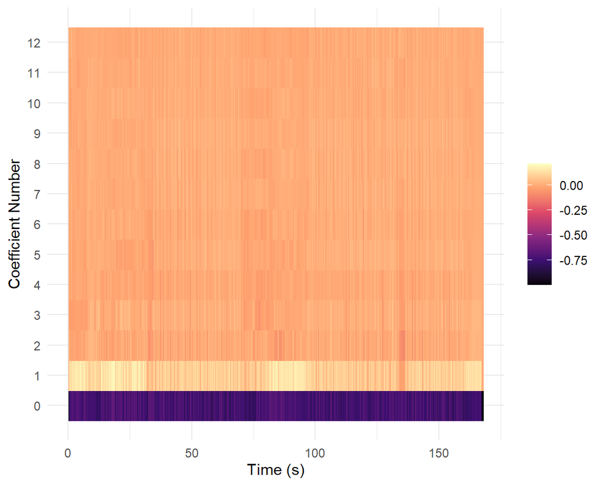

#### Spectral novelty

The sudden changes are better visualized in the spectral novelty graph. This graphs shows a lot of sudden and high peaks in the sections that correlate with the drops of the song.

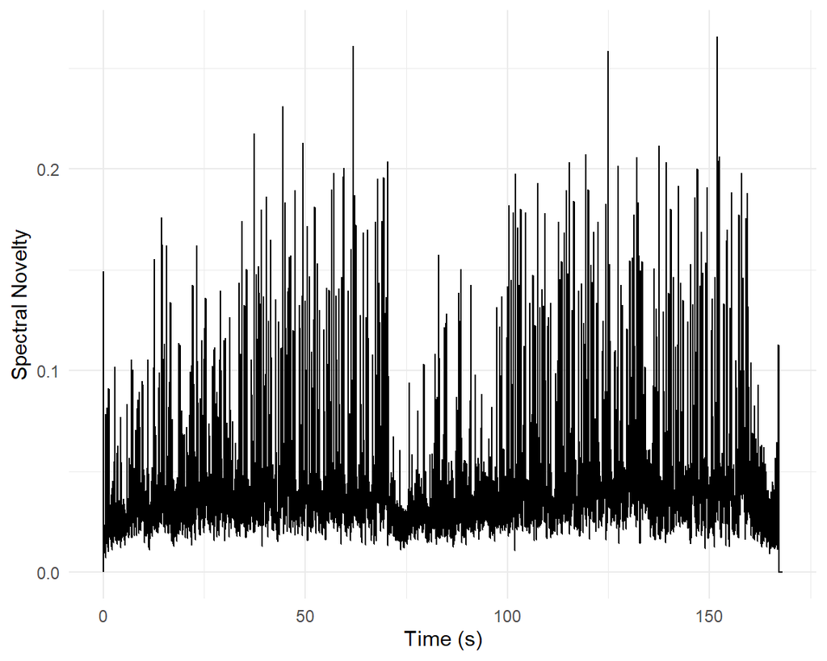

# Classification

### Baseline

To be able to classify the songs in the corpus and determine if a song is made by an AI or not, an algorithm will be used. Namely, the k-nearest neighbour (knn) algorithm. Using 1 neighbour and all available features to check the performance.

All the features in the corpus are:

- Arousal: Describes overall intensity or excitement in the music.
- Danceability: Measures how suitable a track is for dancing, factoring in rhythm stability, beat clarity, and tempo.
- Instrumentalness: Indicates how “instrumental” the track is. Higher values imply fewer (or no) vocals.
- Tempo: The speed of the track, measured in beats per minute (BPM).
- Valence: Suggests the “positiveness” or emotional tone of the music. Higher values mean happier, more upbeat vibes.
- Approachability: Reflects how easily a casual listener can enjoy the song, linked to familiar structures or less abrasive sounds.
- Engagingness: Describes how effectively a track holds the listener’s attention, often influenced by dynamic shifts and captivating elements.

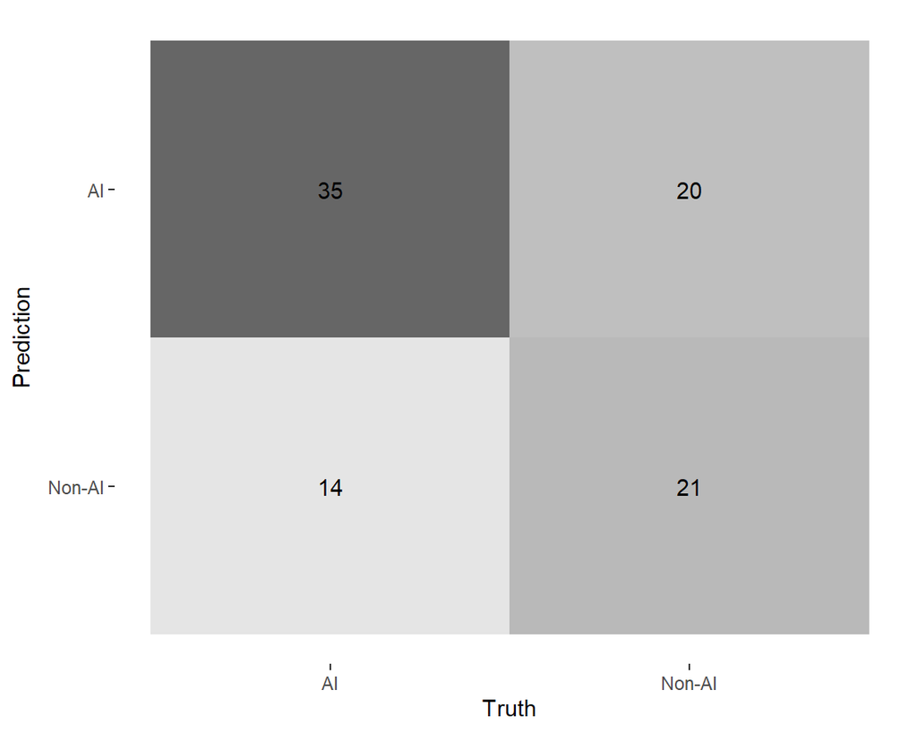

```
# A tibble: 2 × 3
  class  precision recall
  <fct>      <dbl>  <dbl>
1 AI         0.636  0.714
2 Non-AI     0.6    0.512
```

#### Feature importance

The heatmap shows us the accuracy of the algorithm. Both the top-left and bottom-right squares are correct classifications while the other 2 are false positives (top-right) and false negatives (bottom-left) for AI. Using all the features available gives a really low average precision and recall.

Using a random forest model we can determine the importance of each feature.

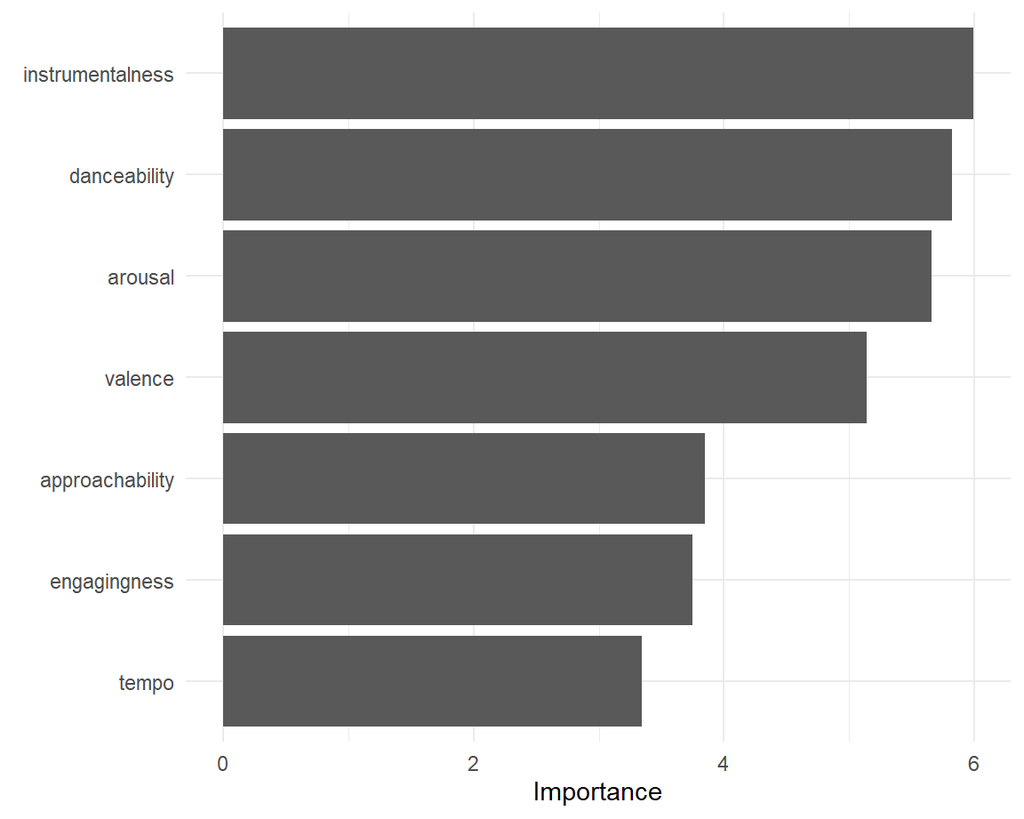

The feature with the least importance is “tempo” and is not unexpected. Tempo varies all the time and is not a good indicator if a song is AI since every genre of music has different tempos. Engagingness and approachability also seem, after some testing, to negatively impact the results of the prediction. This means that the tempo, engagingness and approachibility are not good predictors for this model and will therefore be removed in the adjusted model.

### Adjusted heatmap

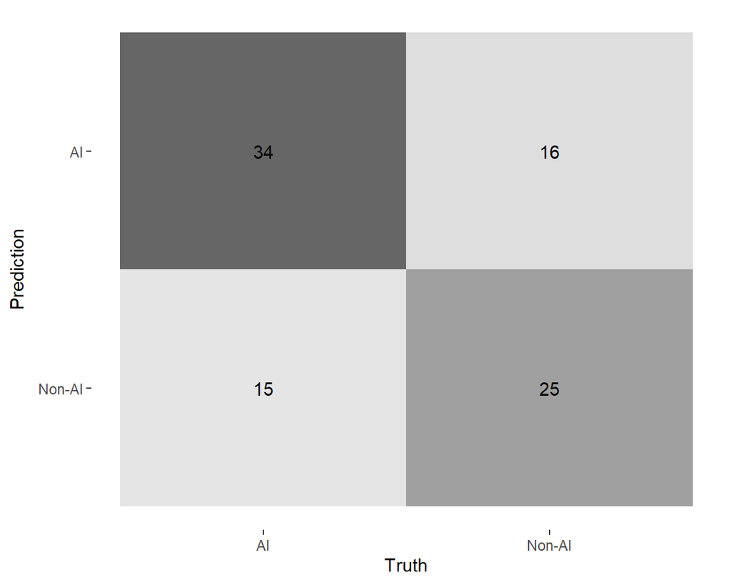

```
# A tibble: 2 × 3
  class  precision recall
  <fct>      <dbl>  <dbl>
1 AI         0.68   0.694
2 Non-AI     0.625  0.610
```

# Conclusion

### Visualization conclusion

Here is a visualization from the 4 most important features and the visualization of from the ‘Introduction’ page.

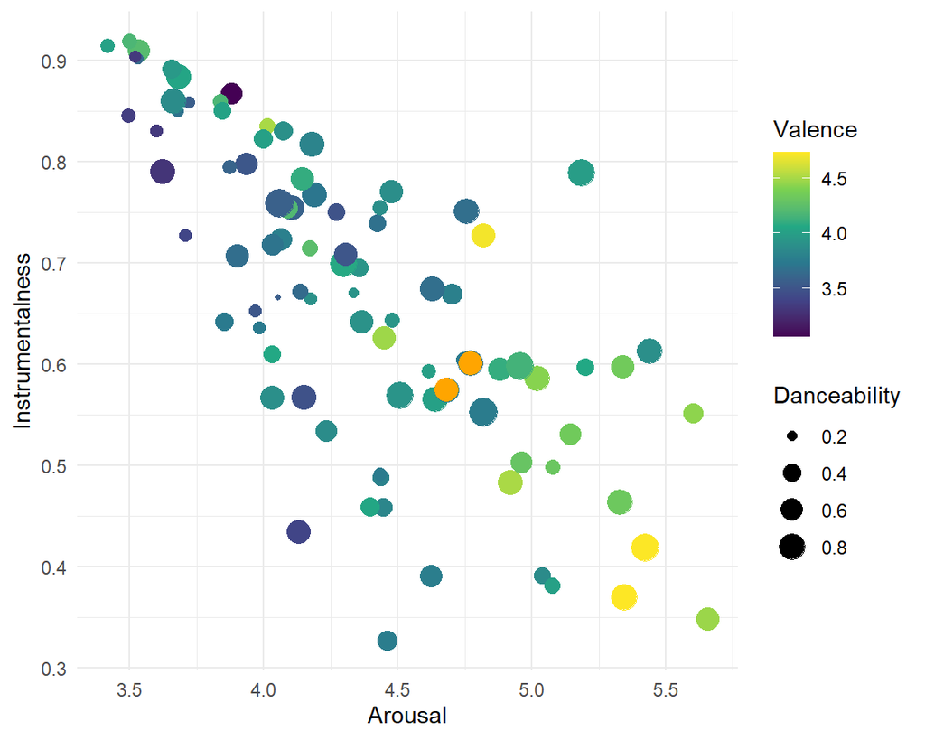

If we compare these two visualizations we see that Non-AI songs often have a combination of higher instrumentalness and arousal than AI-made songs, but this is just an observation from the visualization and the feature importance from the “classifcation” tab.

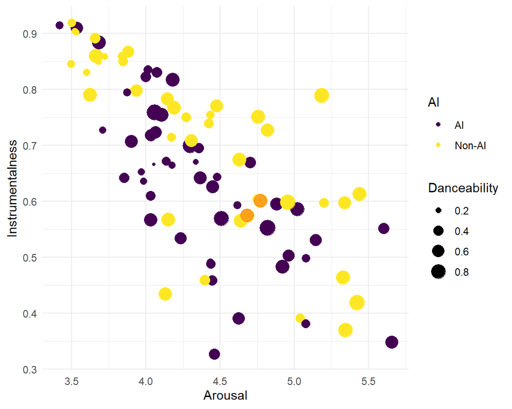

### Conclusion

These findings can benefit anyone looking to build music recommendation or automatic classification systems, as well as artists who are interested in how certain audio attributes (e.g., energy, valence) align with listener perception of the music. Understanding feature importance helps streamline future music analyses and enables more efficient data-driven approaches to everything from playlist management to AI-generated music detection.